# B_AURORA_exploring_phenotype_data

Jan. 21, 2020

```
[1] "/opt/R/3.6.2/lib/R/library"
[2] "/PHShome/bm363/R/x86_64-pc-linux-gnu-library/3.6"
```

## load relevant datasets

A subset of phenotype with the most relevant phenotypes.

| FID | IID | PID | ED_PDI_RS.x | ED_GenderNow | ED_Age | BMI | ED_Marital | ED_RaceEthCode | ED_HighestGrade | M3_PCL5_RS | M3_PCL5 | M3_PROM_Dep8b_T | M3_PROM_Dep8b | WK2_CTQSF_Total_RS | ED_Event_BroadClass | ED_Event_SpecificClass | EA4 |
| --- | --- | --- | --- | --- | --- | --- | --- | --- | --- | --- | --- | --- | --- | --- | --- | --- | --- |
| 202856670162_R10C02 | PT-2LO8G | 100092 | 20 | 2 | 29 | NA | 6 | 3 | 17 | 26 | 0 | 59 | 0 | NA | 1 | 1 | NA |
| 203020860113_R01C02 | PT-2LPUQ | 100125 | 18 | 1 | 41 | NA | 6 | 1 | 17 | NA | NA | NA | NA | NA | 2 | 9 | NA |
| 203013280034_R07C02 | PT-2LO8R | 100145 | 23 | 2 | 36 | NA | 6 | 4 | 18 | NA | NA | NA | NA | NA | 1 | 1 | NA |
| 202995720013_R02C01 | PT-2LPSD | 100170 | 17 | 2 | 56 | NA | 3 | 2 | 15 | 35 | 1 | 62 | 1 | 18 | 1 | 1 | NA |
| 203000560083_R09C02 | PT-2LPT2 | 102642 | 15 | 1 | 60 | 24 | 6 | 2 | 16 | 28 | 1 | 60 | 0 | 20 | 1 | 2 | NA |
| 203020850102_R02C02 | PT-2LPSP | 100203 | 28 | 2 | 46 | NA | 6 | 1 | 19 | NA | NA | NA | NA | 1 | 1 | 1 | 1 |
| 203013280158_R04C02 | PT-2LPU3 | 100311 | 1 | 2 | 33 | NA | 6 | 3 | 15 | 0 | 0 | 37 | 0 | 0 | 2 | 9 | NA |
| 203020840039_R11C01 | PT-2LO94 | 100339 | 13 | 2 | 56 | NA | 5 | 1 | 12 | 35 | 1 | 61 | 1 | NA | 1 | 1 | NA |
| 203013280245_R04C02 | PT-2LPT3 | 100325 | 24 | 1 | 40 | NA | 3 | 1 | 14 | 38 | 1 | 57 | 0 | 24 | 1 | 1 | NA |
| 203009210107_R10C02 | PT-2LPOG | 100375 | 6 | 2 | 52 | NA | 2 | 3 | 11 | 5 | 0 | 48 | 0 | NA | 2 | 8 | NA |

[output cut: 990 more lines]

## PTSD diagnosis and severity score

Total severity score based on a 20 item questionaire (resulting in a range 0 to 80). We used this score taken at 3 months follow-up survey.

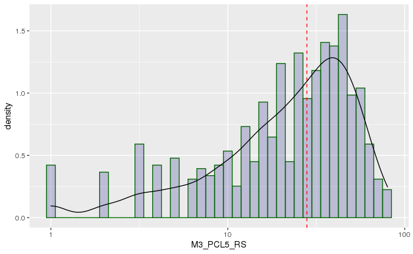

A cut point of 28 (instead of 33 as usual or recommended?) was used to determine a binary diagnosis indicator variable. PTSD cases are those with a score of 28 or more.

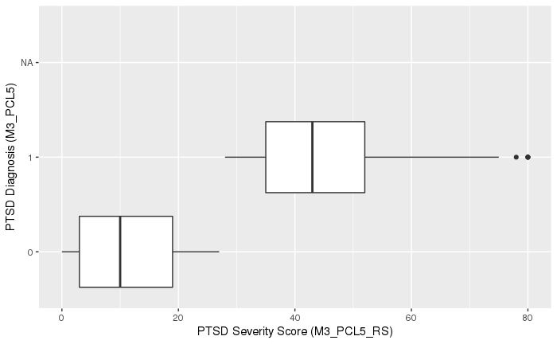

Let’s briefly summarize some relevant survey scores for the PTSD cases and controls.

| M3_PCL5 | n | mean_PCL | mean_CTQSF | mean_PROM_Dep |
| --- | --- | --- | --- | --- |
| 0 | 461 | 11 | 7.0 | 47 |
| 1 | 348 | 44 | 12.7 | 63 |
| NA | 478 | NaN | 8.7 | 53 |

Let’s redo the above plot with number of cases and controls inserted

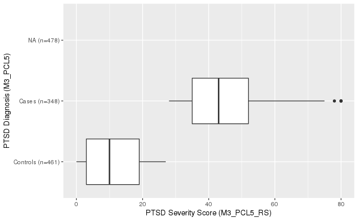

## MDD diagnosis and severity score

Total severity score based on PROMIS Depression - Short Form 8b (raw score range from 8 to 40). (Note that this raw score is not available.) This raw score is standardized to a T-score with a mean of 50 and standard deviation of 10 (resulting in a range 37.1-81.1). We used this score taken at 3 months follow-up survey.

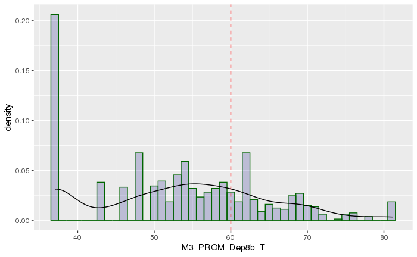

A cut point of 60 of the T-score was used to determine a binary diagnosis indicator variable. Depression cases are those with a T-score of 60 or more.

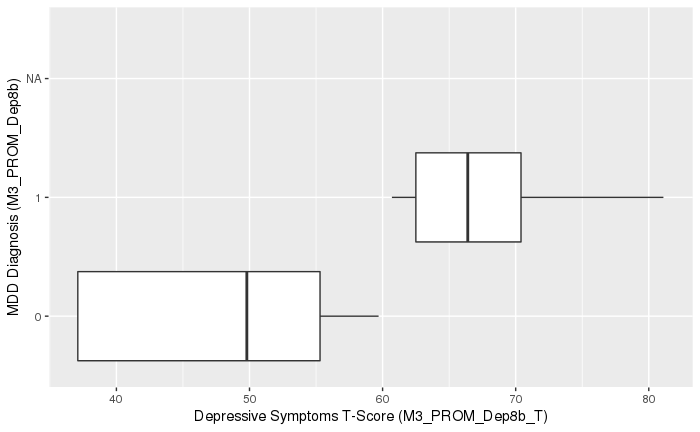

Let’s briefly summarize some relevant survey scores for the MDD cases and controls.

| M3_PROM_Dep8b | n | mean_PCL | mean_CTQSF | mean_PROM_Dep |
| --- | --- | --- | --- | --- |
| 0 | 589 | 17 | 7.5 | 48 |
| 1 | 226 | 46 | 14.7 | 67 |
| NA | 472 | NaN | 8.9 | NaN |

Let’s redo the above plot with number of cases and controls inserted

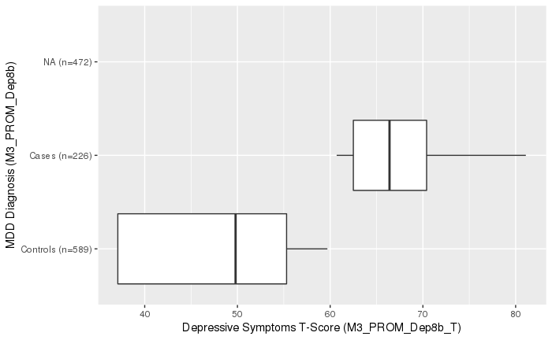

## Childhood trauma

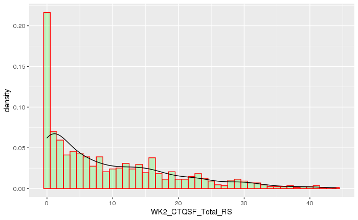

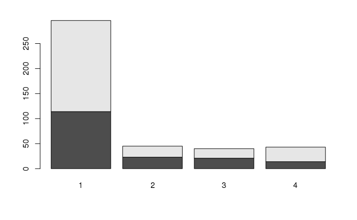

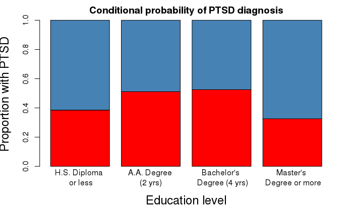

| PTSD_status | n | PCL_mean | PCL_se | Dep_mean | Dep_se | Age_mean | Age_se | BMI_mean | BMI_se | CT_mean | CT_se |
| --- | --- | --- | --- | --- | --- | --- | --- | --- | --- | --- | --- |
| Controls | 461 | 11 | 0.40 | 47 | 0.39 | 36 | 0.65 | 30 | 0.38 | 7 | 0.38 |
| Cases | 348 | 44 | 0.64 | 63 | 0.43 | 37 | 0.68 | 31 | 0.49 | 13 | 0.59 |

|  | 0 (N=461) | 1 (N=348) | Total (N=809) | p value |
| --- | --- | --- | --- | --- |
| **M3_PCL5_RS** |  |  |  | < 0.001 |
| N-Miss | 9 | 12 | 21 |  |
| Mean (SD) | 11.137 (8.672) | 44.268 (11.938) | 25.264 (19.302) |  |
| Range | 0.000 - 27.000 | 28.000 - 80.000 | 0.000 - 80.000 |  |
| **M3_PROM_Dep8b_T** |  |  |  | < 0.001 |
| Mean (SD) | 46.601 (8.326) | 62.628 (7.933) | 53.495 (11.381) |  |
| Range | 37.100 - 69.300 | 37.100 - 81.100 | 37.100 - 81.100 |  |
| **ED_Age** |  |  |  | 0.497 |
| Mean (SD) | 36.087 (13.926) | 36.736 (12.775) | 36.366 (13.439) |  |
| Range | 18.000 - 74.000 | 18.000 - 69.000 | 18.000 - 74.000 |  |
| **as.factor(ED_GenderNow)** |  |  |  | 0.003 |
| 1 | 178 (38.6%) | 96 (27.6%) | 274 (33.9%) |  |
| 2 | 283 (61.4%) | 251 (72.1%) | 534 (66.0%) |  |
| 3 | 0 (0.0%) | 1 (0.3%) | 1 (0.1%) |  |
| **BMI** |  |  |  | 0.447 |
| N-Miss | 102 | 61 | 163 |  |
| Mean (SD) | 30.071 (8.201) | 30.593 (9.216) | 30.303 (8.664) |  |
| Range | 17.300 - 78.700 | 13.800 - 76.900 | 13.800 - 78.700 |  |
| **ED_HighestGrade** |  |  |  | 0.038 |
| N-Miss | 1 | 2 | 3 |  |
| Mean (SD) | 15.046 (2.494) | 14.662 (2.717) | 14.881 (2.597) |  |
| Range | 9.000 - 21.000 | 1.000 - 21.000 | 1.000 - 21.000 |  |
| **WK2_CTQSF_Total_RS** |  |  |  | < 0.001 |
| N-Miss | 34 | 32 | 66 |  |
| Mean (SD) | 6.995 (8.111) | 12.712 (11.044) | 9.427 (9.877) |  |
| Range | 0.000 - 39.000 | 0.000 - 44.000 | 0.000 - 44.000 |  |

|  | Controls (N=461) | Cases (N=348) | Overall (N=809) |
| --- | --- | --- | --- |
| PCL score |  |  |  |
| Mean (SD) | 11.1 (8.67) | 44.3 (11.9) | 25.3 (19.3) |
| Median [Min, Max] | 10.0 [0, 27.0] | 43.0 [28.0, 80.0] | 23.0 [0, 80.0] |
| Missing | 9 (2.0%) | 12 (3.4%) | 21 (2.6%) |
| Depressive symptom T score |  |  |  |
| Mean (SD) | 46.6 (8.33) | 62.6 (7.93) | 53.5 (11.4) |
| Median [Min, Max] | 48.2 [37.1, 69.3] | 61.6 [37.1, 81.1] | 54.3 [37.1, 81.1] |
| Age |  |  |  |
| Mean (SD) | 36.1 (13.9) | 36.7 (12.8) | 36.4 (13.4) |
| Median [Min, Max] | 32.0 [18.0, 74.0] | 34.5 [18.0, 69.0] | 33.0 [18.0, 74.0] |
| Gender |  |  |  |
| Male | 178 (38.6%) | 96 (27.6%) | 274 (33.9%) |
| Female | 283 (61.4%) | 251 (72.1%) | 534 (66.0%) |
| Transgender | 0 (0%) | 1 (0.3%) | 1 (0.1%) |
| BMI |  |  |  |
| Mean (SD) | 30.1 (8.20) | 30.6 (9.22) | 30.3 (8.66) |
| Median [Min, Max] | 28.5 [17.3, 78.7] | 28.8 [13.8, 76.9] | 28.7 [13.8, 78.7] |
| Missing | 102 (22.1%) | 61 (17.5%) | 163 (20.1%) |
| ED_HighestGrade |  |  |  |
| Mean (SD) | 15.0 (2.49) | 14.7 (2.72) | 14.9 (2.60) |
| Median [Min, Max] | 15.0 [9.00, 21.0] | 15.0 [1.00, 21.0] | 15.0 [1.00, 21.0] |
| Missing | 1 (0.2%) | 2 (0.6%) | 3 (0.4%) |
| Childhood trauma score |  |  |  |
| Mean (SD) | 7.00 (8.11) | 12.7 (11.0) | 9.43 (9.88) |
| Median [Min, Max] | 4.00 [0, 39.0] | 11.0 [0, 44.0] | 6.00 [0, 44.0] |
| Missing | 34 (7.4%) | 32 (9.2%) | 66 (8.2%) |
| Race/Ethnicity |  |  |  |
| Hispanic | 48 (10.4%) | 46 (13.2%) | 94 (11.6%) |
| White | 125 (27.1%) | 113 (32.5%) | 238 (29.4%) |
| Black | 271 (58.8%) | 176 (50.6%) | 447 (55.3%) |
| Asian | 16 (3.5%) | 12 (3.4%) | 28 (3.5%) |
| Missing | 1 (0.2%) | 1 (0.3%) | 2 (0.2%) |

Descriptive stat table with MDD case and control

|  | Controls (N=589) | Cases (N=226) | Overall (N=815) |
| --- | --- | --- | --- |
| PCL score |  |  |  |
| Mean (SD) | 17.3 (14.5) | 46.1 (14.2) | 25.3 (19.3) |
| Median [Min, Max] | 15.0 [0, 71.0] | 45.0 [3.00, 80.0] | 23.0 [0, 80.0] |
| Missing | 19 (3.2%) | 8 (3.5%) | 27 (3.3%) |
| Depressive symptom T score |  |  |  |
| Mean (SD) | 48.2 (8.07) | 67.3 (5.65) | 53.5 (11.3) |
| Median [Min, Max] | 49.8 [37.1, 59.7] | 66.4 [60.7, 81.1] | 54.3 [37.1, 81.1] |
| Age |  |  |  |
| Mean (SD) | 37.0 (13.8) | 35.2 (12.6) | 36.5 (13.5) |
| Median [Min, Max] | 34.0 [18.0, 74.0] | 32.0 [18.0, 70.0] | 33.0 [18.0, 74.0] |
| Gender |  |  |  |
| Male | 211 (35.8%) | 64 (28.3%) | 275 (33.7%) |
| Female | 378 (64.2%) | 161 (71.2%) | 539 (66.1%) |
| Transgender | 0 (0%) | 1 (0.4%) | 1 (0.1%) |
| BMI |  |  |  |
| Mean (SD) | 30.4 (8.29) | 30.0 (9.52) | 30.3 (8.66) |
| Median [Min, Max] | 29.0 [17.3, 78.7] | 28.2 [13.8, 76.9] | 28.7 [13.8, 78.7] |
| Missing | 126 (21.4%) | 37 (16.4%) | 163 (20.0%) |
| ED_HighestGrade |  |  |  |
| Mean (SD) | 14.9 (2.60) | 14.8 (2.59) | 14.9 (2.60) |
| Median [Min, Max] | 15.0 [1.00, 21.0] | 15.0 [1.00, 21.0] | 15.0 [1.00, 21.0] |
| Missing | 1 (0.2%) | 2 (0.9%) | 3 (0.4%) |
| Childhood trauma score |  |  |  |
| Mean (SD) | 7.46 (8.41) | 14.7 (11.5) | 9.40 (9.86) |
| Median [Min, Max] | 4.00 [0, 40.0] | 12.0 [0, 44.0] | 6.00 [0, 44.0] |
| Missing | 42 (7.1%) | 25 (11.1%) | 67 (8.2%) |
| Race/Ethnicity |  |  |  |
| Hispanic | 65 (11.0%) | 29 (12.8%) | 94 (11.5%) |
| White | 161 (27.3%) | 78 (34.5%) | 239 (29.3%) |
| Black | 340 (57.7%) | 111 (49.1%) | 451 (55.3%) |
| Asian | 22 (3.7%) | 7 (3.1%) | 29 (3.6%) |
| Missing | 1 (0.2%) | 1 (0.4%) | 2 (0.2%) |